# LICOR 6400XT

Stefan Roeder

7/1/2021

### Background

We will use a fictional dataset.

Research question: Do scion and rootstock affect leaf gas exchange in apple?

Explanatory variables: - rootstock (2 levels) - scion (5 levels)

Response variables: - Carbon dioxide assimilation rate (Photo) - Transpiration rate (Trmmol) - Conductance (Cond)

Experimental design: - subsampling (two readings per tree)

Note: - I will be using the emmeans package. Thus, the reported means are estimated marginal means.

### Install and Load Required Packages

```r
if (!require('nlme')) install.packages('nlme')
library('nlme')

if (!require('emmeans')) install.packages('emmeans')
library('emmeans')

if (!require('multcomp')) install.packages('multcomp')
library('multcomp')

if (!require('multcompView')) install.packages('multcompView')
library('multcompView')

if (!require('ggplot2')) install.packages('ggplot2')
library('ggplot2')

if (!require('ggpubr')) install.packages('ggpubr')
library('ggpubr')
```

### Import Dataset

```r
mydata <- read.delim(url("https://raw.githubusercontent.com/StefanRoederGit/Statistics-for-Horticulturists-using-R/main/LICOR6400XT/Dataset/LICOR-6400XT.txt"),stringsAsFactors=TRUE)
```

### Convert to Factor Variables

```r
mydata$Rootstock <- as.factor(mydata$Rootstock)
mydata$Scion <- as.factor(mydata$Scion)
mydata$Tree <- as.factor(mydata$Tree)
```

### Fit Linear Mixed Model, Run ANOVA, and Perform Multiple Comparision Procedure

#### CO2 Assimilation Rate (Photo)

```r
fit <- lme(Photo ~ Rootstock * Scion, data = mydata, random = ~1|Tree)
anova(fit)
```

```
##                 numDF denDF   F-value p-value
## (Intercept)         1    27 1953.4370  <.0001
## Rootstock           1    27   14.9000  0.0006
## Scion               4    27    5.3701  0.0026
## Rootstock:Scion     4    27    1.7046  0.1781
```

```r
lm.emmGrid <- emmeans(fit, pairwise ~ Rootstock)
cld(lm.emmGrid[[1]], Letters = letters)
```

```
##  Rootstock emmean    SE df lower.CL upper.CL .group
##  G.11        15.3 0.538 23     14.2     16.5  a
##  G.41        18.3 0.538 22     17.2     19.4   b
##
## Results are averaged over the levels of: Scion
## Degrees-of-freedom method: containment
## Confidence level used: 0.95
## significance level used: alpha = 0.05
```

The average assimilation rate of G.11 (mean = 15.3 μmol m−2 s−1) was significant lower when compared to G.41 (mean = 18.3 μmol m−2 s−1).

```r
lm.emmGrid <- emmeans(fit, pairwise ~ Scion)
cld(lm.emmGrid[[1]], Letters = letters)
```

```
##  Scion            emmean    SE df lower.CL upper.CL .group
##  Red Delicious      14.6 0.851 23     12.8     16.3  a
##  Fuji               15.8 0.851 23     14.1     17.6  a
##  Golden Delicious   16.3 0.851 22     14.5     18.0  ab
##  Gala               17.7 0.851 23     16.0     19.5  ab
##  Granny Smith       19.7 0.851 23     17.9     21.5   b
##
## Results are averaged over the levels of: Rootstock
## Degrees-of-freedom method: containment
## Confidence level used: 0.95
## P value adjustment: tukey method for comparing a family of 5 estimates
## significance level used: alpha = 0.05
```

Furthermore, ‘Granny Smith’ showed with 19.7 μmol m−2 s−1 significantly higher assimilation rates than ‘Red Delicious’ (mean = 14.6 μmol m−2 s−1) and ‘Fuji’ (mean = 15.8 μmol m−2 s−1). The assimilation rate of ‘Golden Delicious’ (mean = 16.3 μmol m−2 s−1) and ‘Gala’ (17.7 μmol m−2 s−1) did not differ from ‘Red Delicious’, ‘Fuji’, and ‘Granny Smith’.

#### Plot Data (emmeans +/- 95% confidence intervals)

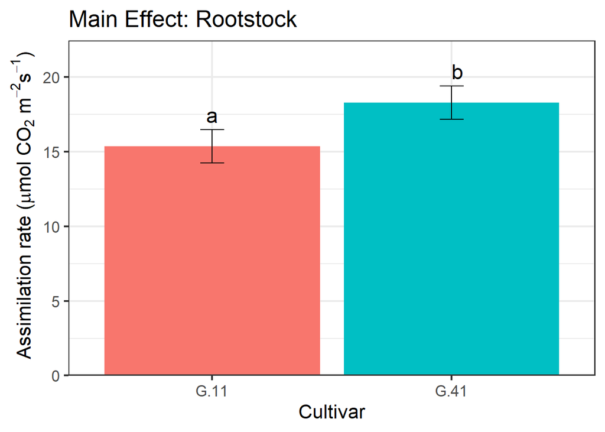

```r
lm.emmGrid <- emmeans(fit, pairwise ~ Rootstock)
clddata <- cld(lm.emmGrid[[1]], Letters = letters)

ggplot(clddata, aes(x = Rootstock, y = emmean, fill = Rootstock)) +
  geom_bar(stat="identity", position = position_dodge()) +
  geom_errorbar(aes(ymin = lower.CL, ymax = upper.CL), width = 0.1, position=position_dodge(.9)) +
  theme_bw(base_size = 16) +
  ggtitle("Main Effect: Rootstock") +
  xlab("Cultivar") +
  ylab(~paste("Assimilation rate (", mu, "mol CO"[2], " m"^-2,"s"^-1,")"))+
  ylim(0,25) +
  scale_y_continuous(expand = expansion(mult = c(0, .1))) +
  geom_text(data = clddata, aes(y= upper.CL + 1, label = .group),  size = 6,position=position_dodge(.9)) +
  theme(legend.position = "none")
```

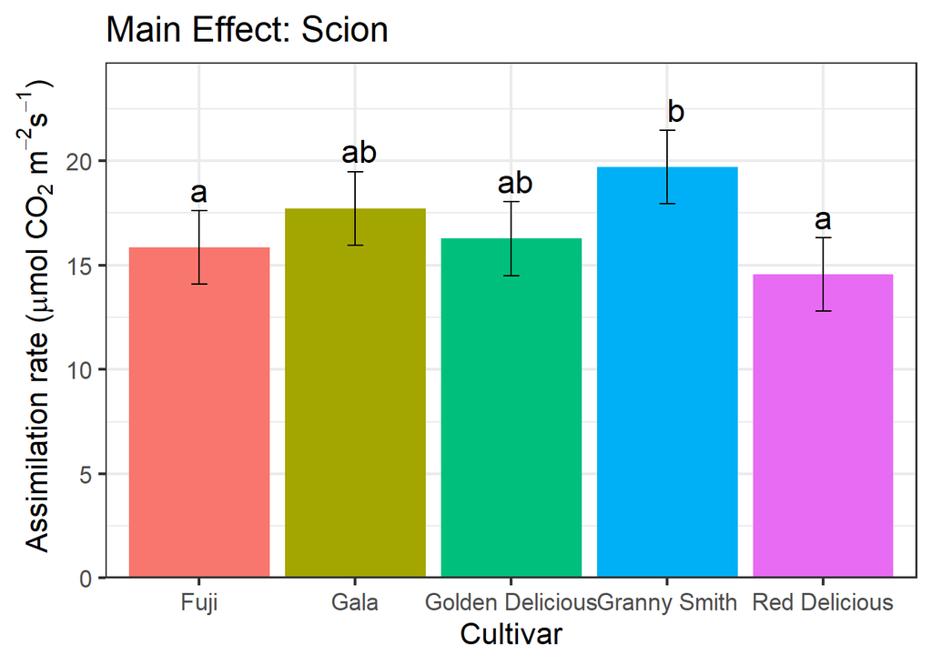

```r
lm.emmGrid <- emmeans(fit, pairwise ~ Scion)
clddata <- cld(lm.emmGrid[[1]], Letters = letters)

ggplot(clddata, aes(x = Scion, y = emmean, fill = Scion)) +
  geom_bar(stat="identity", position = position_dodge()) +
  geom_errorbar(aes(ymin = lower.CL, ymax = upper.CL), width = 0.1, position=position_dodge(.9)) +
  theme_bw(base_size = 16) +
  ggtitle("Main Effect: Scion") +
  xlab("Cultivar") +
  ylab(~paste("Assimilation rate (", mu, "mol CO"[2], " m"^-2,"s"^-1,")")) +
  ylim(0,25) +
  scale_y_continuous(expand = expansion(mult = c(0, .1))) +
  geom_text(data = clddata, aes(y= upper.CL + 1, label = .group),  size = 6) +
  theme(legend.position = "none")
```